# Analysis_1st

Ryuta

2026-01-05

# 目的

熱交換器の詰まり本数と各運転パラメータ（U値、ジャケット圧、ポンプ圧）の相関関係を分析し、詰まりの発生要因を特定することを目的とする。

## データ読み込み

### 時系列データ

|  | Timestamp | U | jacket_P | pump_outlet | Period |
| --- | --- | --- | --- | --- | --- |
| 1 | 2021-03-13T00:00:00Z | 1034.277978582473 | -6.947793 | 0.4726734 | 2103 |
| 2 | 2021-03-14T00:00:00Z | 1013.423530442841 | -6.153581 | 2.50029 | 2103 |
| 3 | 2021-03-15T00:00:00Z | 962.523308240442 | -4.486249 | 3.49404 | 2103 |
| 4 | 2021-03-16T00:00:00Z | 903.7529535266839 | -5.463575 | 3.798922 | 2103 |
| 5 | 2021-03-17T00:00:00Z | 839.9878873661072 | -4.15233 | 4.953213 | 2103 |
| 6 | 2021-03-18T00:00:00Z | 847.7818931749055 | -4.065104 | 5.798647 | 2103 |
| 7 | 2021-03-19T00:00:00Z | 815.8681045909677 | -3.683111 | 5.542443 | 2103 |
| 8 | 2021-03-20T00:00:00Z | 775.3574720473782 | -3.102773 | 5.925165 | 2103 |
| 9 | 2021-03-21T00:00:00Z | 731.0419992822625 | -1.988565 | 7.894578 | 2103 |
| 10 | 2021-03-22T00:00:00Z | 758.7539117153805 | -2.447289 | 7.400273 | 2103 |

[output cut: 1826 more lines]

### 詰まりデータ

|  | U | 詰まり本数 | PI | Flow | Timestamp | Period | production | jacket_P | b/e | PeriodType |
| --- | --- | --- | --- | --- | --- | --- | --- | --- | --- | --- |
| 1 | 440.135270717995 | 245 | 76.9620505848158 | 2345.18258233424 | 2013-07-14T00:00:00Z | 1212 | 101.203 |  | End | 1212_End |
| 2 | 447.573656697992 | 304 | 77.0693387210526 | 2346.9675072189 | 2014-03-04T00:00:00Z | 1308 | 102.363808 |  | End | 1308_End |
| 3 | 430.340107094669 | 23 | 76.8997001660724 | 2344.14051480638 | 2016-11-17T00:00:00Z | 1604 | -0.131667346 |  | End | 1604_End |
| 4 | 441.991665318091 | 84 | 77.0122287513158 | 2346.0186730572 | 2017-07-05T00:00:00Z | 1612 | 95.91598 |  | End | 1612_End |
| 5 | 448.519154027179 | 223 | 77.064347131579 | 2346.88469322601 | 2018-03-25T00:00:00Z | 1708 | 95.93339 |  | End | 1708_End |
| 6 | 501.76577295221 | 79 | 77.2585884898026 | 2350.09075198362 | 2019-02-13T00:00:00Z | 1806 | 95.50362 |  | End | 1806_End |
| 7 | 506.214559310089 | 163 | 77.2080859766447 | 2349.2604473802 | 2019-09-16T00:00:00Z | 1903 | 96.21576 |  | End | 1903_End |
| 8 | 440.746498497532 | 264 | 76.9080302676415 | 2344.27993896204 | 2020-04-20T00:00:00Z | 1910 | -0.0361136273 |  | End | 1910_End |
| 9 | 662.445761848089 | 233 | 77.3438414782895 | 2112.58973319581 | 2021-02-02T00:00:00Z | 2011 | 117.520119 | 1.14950156 | End | 2011_End |
| 10 | 384.198123770814 | 196 | 77.2130451554507 | 1604.03800410107 | 2021-09-08T00:00:00Z | 2103 | 111.245834 | 14.7946186 | End | 2103_End |

[output cut: 9 more lines]

## パラメータ推移

各パラメータ（U値、ジャケット圧、ポンプ圧）の推移を時系列グラフで確認する。

### U値

[interactive chart not shown]

### ジャケット圧

[interactive chart not shown]

### ポンプ圧

[interactive chart not shown]

## データ加工と分析

各パラメータ（U値、ジャケット圧、ポンプ圧）について、キャンペーンの初期・末期の最大値を抽出し、詰まり本数（NoS）との相関を分析する。

### Case1) UA

U値の最大値からUAを算出し、相関を確認する。

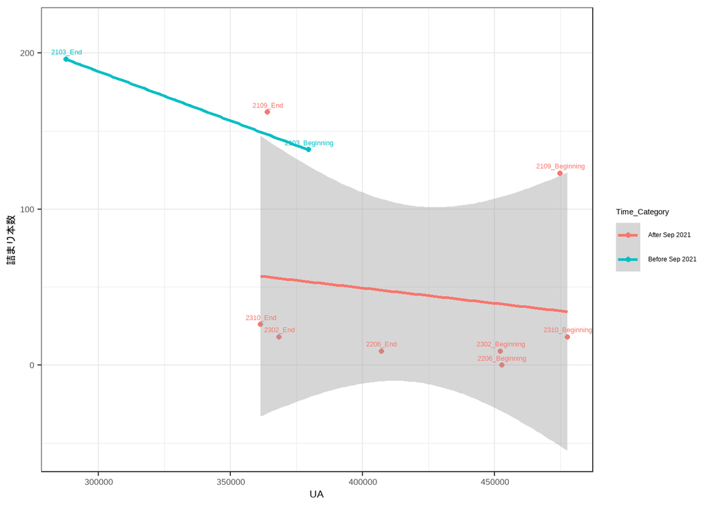

```
##
## Call:
## lm(formula = y_val ~ x_val)
##
## Residuals:
##    Min     1Q Median     3Q    Max
## -74.97 -52.38 -14.33  51.60 101.86
##
## Coefficients:
##               Estimate Std. Error t value Pr(>|t|)
## (Intercept)  3.415e+02  1.482e+02   2.304   0.0502 .
## x_val       -6.746e-04  3.644e-04  -1.851   0.1013
## ---
## Signif. codes:  0 '***' 0.001 '**' 0.01 '*' 0.05 '.' 0.1 ' ' 1
##
## Residual standard error: 67.11 on 8 degrees of freedom
## Multiple R-squared:  0.2999, Adjusted R-squared:  0.2124
## F-statistic: 3.427 on 1 and 8 DF,  p-value: 0.1013
```

### Case2) ジャケット圧

ジャケット圧（jacket_P）の最大値と詰まり本数の相関を確認する。

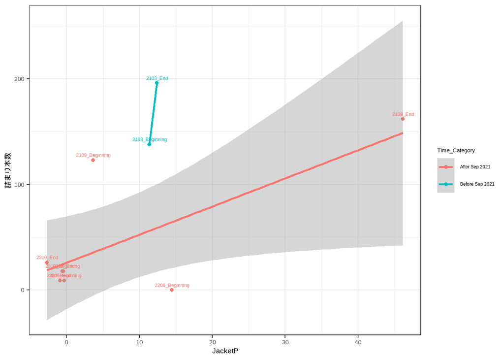

```
##
## Call:
## lm(formula = y_val ~ x_val)
##
## Residuals:
##    Min     1Q Median     3Q    Max
## -88.81 -30.65 -24.50  41.52 113.50
##
## Coefficients:
##             Estimate Std. Error t value Pr(>|t|)
## (Intercept)   44.312     23.604   1.877   0.0973 .
## x_val          3.080      1.452   2.121   0.0667 .
## ---
## Signif. codes:  0 '***' 0.001 '**' 0.01 '*' 0.05 '.' 0.1 ' ' 1
##
## Residual standard error: 64.16 on 8 degrees of freedom
## Multiple R-squared:   0.36,  Adjusted R-squared:   0.28
## F-statistic:   4.5 on 1 and 8 DF,  p-value: 0.06668
```

### Case3) ポンプ圧

ポンプ吐出圧（pump_outlet）の最大値と詰まり本数の相関を確認する。

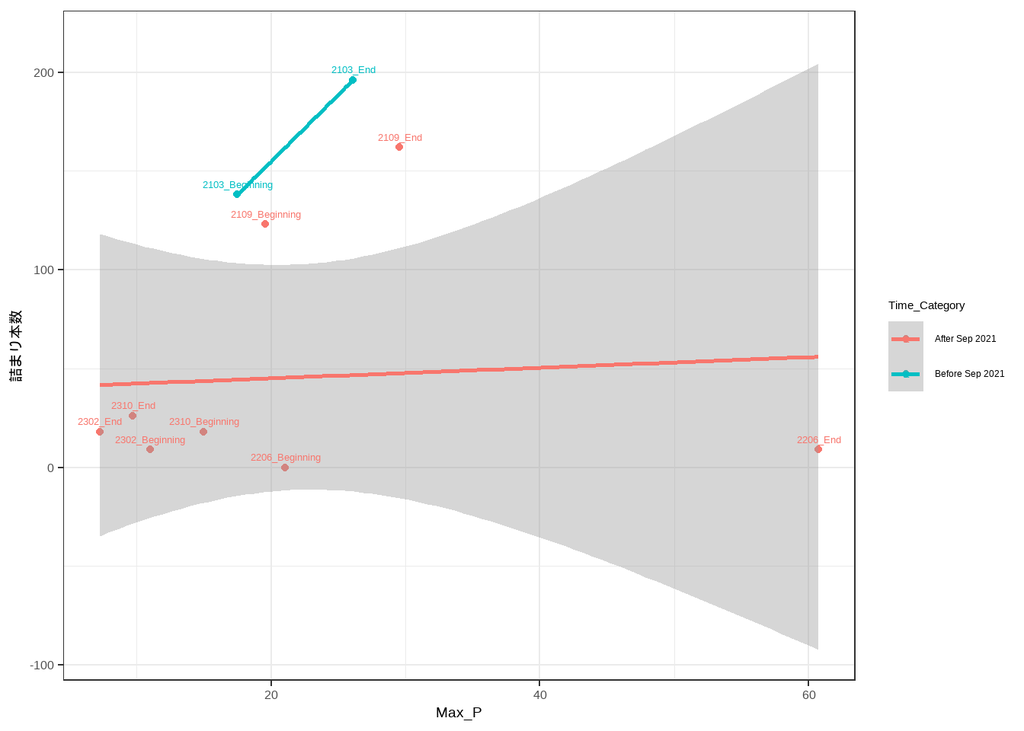

```
##
## Call:
## lm(formula = y_val ~ x_val)
##
## Residuals:
##    Min     1Q Median     3Q    Max
## -75.89 -54.90 -42.80  65.78 124.43
##
## Coefficients:
##             Estimate Std. Error t value Pr(>|t|)
## (Intercept)  61.5425    45.2843   1.359    0.211
## x_val         0.3844     1.7277   0.222    0.830
##
## Residual standard error: 79.96 on 8 degrees of freedom
## Multiple R-squared:  0.006148,   Adjusted R-squared:  -0.1181
## F-statistic: 0.04949 on 1 and 8 DF,  p-value: 0.8295
```

### 乖離幅の分析まとめ

予測式との乖離幅が最も大きいプロットについて、全体本数（922本）に対する割合を以下に示す。

|  | Parameter | Period | Max_Deviation | Percentage_of_Total |
| --- | --- | --- | --- | --- |
| 1 | UA | After Sep 2021 | 105.45 | 11.44 |
| 2 | Jacket Pressure | After Sep 2021 | 87.44 | 9.48 |
| 3 | Pump Pressure | After Sep 2021 | 114.28 | 12.39 |